# Spruce budworm flight phenology in Maine

Daily dynamics — analysis log

Author

JN Candau

Published

1 October 2026

# 1 Purpose of this document

This is the running log of the analyses of spruce budworm (*Choristoneura fumiferana*) flight phenology from daily light-trap catches in Maine. Each section records what was done, the choices that were made and why, and the state of the data or the model that resulted. It is updated as the work proceeds; the numbers below are recomputed from the processed data every time the document is rendered, so they cannot drift away from the files on disk.

Code lives in `R/`, source data in `data/raw/`, processed tables in `data/processed/`. The project is version-controlled at https://github.com/jncandau/Maine_Oct_2026.

**Project layout.** This log documents the *Daily dynamics* analysis: the night-by-night distribution of catches. It shares its dataset with a second analysis, *Seasonal dynamics* (`seasonal_dynamics/`). The data layer is common to both and sits at the project root — `R/01_read_trap_data.R`, `R/02_read_weather_data.R`, the two development-model runs `R/03_biosim_phenology.R` and `R/04_pupal_phenology.R`, `R/functions/phenology.R` and `data/`. The scripts cited here as `R/05` to `R/14` and `R/functions/predict_flight.R` live under `daily_dynamics/R/`.

# 2 Trap data

## 2.1 Source

The captures come from the eastern spruce budworm phenology dataset of Fournier, Candau et al. (2027), held in the private repository `jncandau/SBWFieldPhenoDatabase` and copied unmodified into `data/raw/SBWFieldPhenoDatabase/`. The workbook `Eastern Spruce Budworm Phenology V1.ods` holds three tables — `Phenology`, `Flight` and `References` — joined by `referenceID`. Only `Flight` is used here.

`Flight` is a wide table: one row per trapping record, with the captures of each night in the columns `mothsDay160` … `mothsDay231` (day of year 160 to 231). A record is a site × year × sampling method × sex combination, and carries its coordinates, the reported season total `mothCountYear`, and a pointer to the source publication. Across North America it holds 763 records; Maine contributes 643 light-trap records and 36 yard-light records.

## 2.2 Reading and decoding

`R/01_read_trap_data.R` reads the sheet with every column forced to character, because the day columns mix numbers with two text codes:

Table 1: Day-cell codes in the `Flight` sheet

| Cell | Meaning | Handling |
| --- | --- | --- |
| `-` | no count reported | zero inside the season of that year, otherwise the night is dropped |
| `m` | date sampled, value missing | kept as a row with `moths = NA` and `status = "missing"` |
| number | nightly capture | kept, `status = "counted"` |

The two codes are not equivalent. `m` marks a night that was sampled and whose value is lost, and it stays missing. `-` carries no count at all, and what it means depends on when it falls: inside the flight season the trap was running and caught nothing, which is a **zero**; outside it the trap was not operating and the night does not exist.

The season of a year is therefore defined once, from the catches themselves: it runs from the first to the last night on which any trap in the dataset caught a moth that year. Every record of that year is expanded to that window — its own counts where it has them, zeros on the `-` nights, `NA` on the `m` nights — and anything outside the window is dropped. `n_zero_filled` records how many nights each record owes to this rule.

The wide table is then pivoted to one row per record-night, and a calendar date is derived from the year and the day of year.

## 2.3 Selection

Four criteria define the working dataset, all set as constants at the top of `R/01_read_trap_data.R`:

Table 2: Selection criteria

| Criterion | Value | Reason |
| --- | --- | --- |
| `keep_states` | `ME` | the study area |
| `keep_methods` | `Light trap` | excludes the 36 opportunistic yard-light records |
| `keep_years` | 1968–1989 | overlap with the CaSR v3.2 reanalysis in `data/raw/Weather_Maine` (1968–1991) |
| `min_season_total` | > 99 moths | a smaller catch cannot describe a flight curve |

The year window drops 1961–1967 and 2016. The catch threshold removes a further 230 in-window records; it also removes, without needing a separate rule, every record that reports only a season total and no daily series, and all of 1963–1967 and 2016, where no trap anywhere in Maine exceeded 99 moths.

## 2.4 Pooling of sex-split records

Two 1980 localities report the male and the female catch of one trap as separate records. Since the trap is the sampling unit, the pairs are summed night by night before the catch threshold is applied, and the components are removed. Both pairs sampled identical nights with no missing values, so the sums are exact.

Table 3: Pooled sex-split records

| flightID | components | year | locality | nights | season total |
| --- | --- | --- | --- | --- | --- |
| 760 | 760+761 | 1980 | Marshfield Plot 4, Maine | 50 | 281 |
| 762 | 762+763 | 1980 | Bare Island, Maine | 50 | 161 |

Pooling matters beyond tidiness: at Bare Island neither sex reached the threshold alone (83 and 78 moths) but the trap caught 161, so the locality re-enters the dataset.

## 2.5 The resulting dataset

Two tables are written to `data/processed/`:

- `trap_records.rds` — one row per trapping record, with sampling effort, season total and provenance;
- `trap_daily.rds` — one row per record-night that was inside a trapping season, holding the count and its `status`.

Table 4: The working dataset at a glance

| Quantity | Value |
| --- | --- |
| Trapping records | 226 |
| Localities | 49 |
| Years | 22 (1968-1989) |
| Trap-nights with a count | 8,286 |
| Nights coded `m` (missing) | 30 |
| Nights filled with a zero (`-`) | 2,720 |
| Moths counted | 1,099,929 |
| Season total, median (range) | 1,263.5 (100-71,730) |
| Nights per record, median (range) | 35 (17-51) |

Table 5: Sampling effort and catch by year

| year | traps | localities | nights | nights/trap | first DOY | last DOY | moths |
| --- | --- | --- | --- | --- | --- | --- | --- |
| 1968 | 2 | 2 | 56 | 28.0 | 187 | 214 | 394 |
| 1969 | 6 | 6 | 306 | 51.0 | 167 | 217 | 4,725 |
| 1970 | 3 | 3 | 75 | 25.0 | 187 | 211 | 688 |
| 1971 | 12 | 12 | 420 | 35.0 | 182 | 216 | 20,213 |
| 1972 | 10 | 10 | 330 | 33.0 | 183 | 215 | 15,366 |
| 1973 | 16 | 16 | 512 | 32.0 | 182 | 213 | 28,751 |
| 1974 | 21 | 21 | 672 | 32.0 | 183 | 214 | 158,403 |
| 1975 | 22 | 22 | 968 | 44.0 | 176 | 219 | 149,744 |
| 1976 | 13 | 13 | 416 | 32.0 | 174 | 205 | 22,233 |
| 1977 | 10 | 10 | 320 | 32.0 | 180 | 211 | 24,057 |
| 1978 | 12 | 12 | 420 | 35.0 | 174 | 208 | 212,265 |
| 1979 | 13 | 13 | 403 | 31.0 | 177 | 207 | 95,649 |
| 1980 | 17 | 17 | 850 | 50.0 | 168 | 217 | 101,252 |
| 1981 | 14 | 14 | 518 | 37.0 | 171 | 207 | 39,533 |
| 1982 | 17 | 17 | 653 | 38.4 | 178 | 216 | 49,074 |
| 1983 | 17 | 17 | 728 | 42.8 | 178 | 221 | 144,673 |
| 1984 | 8 | 8 | 304 | 38.0 | 170 | 207 | 17,577 |
| 1985 | 7 | 7 | 182 | 26.0 | 182 | 207 | 13,073 |
| 1986 | 3 | 3 | 84 | 28.0 | 182 | 209 | 1,214 |
| 1987 | 1 | 1 | 25 | 25.0 | 181 | 205 | 317 |
| 1988 | 1 | 1 | 17 | 17.0 | 187 | 203 | 180 |
| 1989 | 1 | 1 | 27 | 27.0 | 181 | 207 | 548 |

The network is a rotating panel rather than a fixed set of stations: most localities contribute a handful of years, and the annual number of traps varies with the outbreak and with the Maine Forest Service’s programme.

Table 6: Localities by the number of years they contribute

| years | localities |
| --- | --- |
| 1 | 7 |
| 2 | 9 |
| 3 | 6 |
| 4 | 11 |
| 5 | 1 |
| 6 | 4 |
| 7 | 2 |
| 8 | 2 |
| 9 | 1 |
| 11 | 4 |
| 13 | 1 |
| 14 | 1 |

### 2.5.1 Data quality

The following checks are run by `R/01_read_trap_data.R` at every read. They report problems; they never repair them.

Table 7: Quality checks on the retained records

| Check | Records |
| --- | --- |
| Season total disagrees with the sum of the daily counts | 0 |
| Locality-year with more than one record | 0 |
| Records with nights coded `m` | 4 |
| Records with a night filled as a zero | 213 |

Table 8: The records that owe the most nights to the zero-fill rule

| flightID | year | locality | season | nights counted | filled as zero | season total |
| --- | --- | --- | --- | --- | --- | --- |
| 308 | 1969 | Long A Township, T8 R9, Maine | 167-217 | 51 | 36 | 568 |
| 311 | 1969 | Enfield Township, Maine | 167-217 | 51 | 33 | 100 |
| 496 | 1977 | Elliotsville Township, Maine | 180-211 | 32 | 31 | 200 |
| 300 | 1969 | DeBoulie Mtn., T15 R9, Maine | 167-217 | 51 | 30 | 142 |
| 301 | 1969 | Camp Dana, Oxbow Road, T9 R5, Maine | 167-217 | 51 | 30 | 2,817 |
| 313 | 1969 | Georgetown Township, Maine | 167-217 | 51 | 30 | 344 |
| 299 | 1969 | Cross Lake (Guerette) Maine | 167-217 | 51 | 29 | 754 |
| 542 | 1980 | North Bridgton, Maine | 168-217 | 50 | 29 | 130 |
| 762 | 1980 | Bare Island, Maine | 168-217 | 50 | 29 | 161 |
| 546 | 1980 | Ste. Aurelie, Big Six Township, T6 R19, Maine | 168-217 | 50 | 28 | 2,766 |
| 547 | 1980 | Millinocket, Maine | 168-217 | 50 | 28 | 836 |

Of the 8,286 counted nights, 2,720 are zeros supplied by this rule and 50% of all counted nights caught nothing. Only 30 nights remain missing, all of them `m` codes inside a season window; the large June blocks of `m` codes in 1982 and 1983 fall before the first capture of their year and so leave the dataset with the rest of the out-of-season range.

## 2.6 Minimum effort for phenology

A season total above 99 moths says nothing about whether the trap was running long enough, or at the right time, to describe a flight curve. The rule below matches the requirement to the statistic: for a percentile to be identifiable, the sampling window has to bracket it. If more than 5% of a season’s catch falls on the first night, the 5th percentile sits at or before that night and cannot be located; the same argument applies to p95 and the last night.

Table 9: Effort criteria, set as constants in `R/01_read_trap_data.R`

| Criterion | Threshold | What it protects against |
| --- | --- | --- |
| `min_nights` | ≥ 15 counted nights | percentiles interpolated from too few points |
| `min_coverage` | counted nights / season span ≥ 0.7 | holes inside the season displacing the cumulative curve |
| `max_tail_share` | ≤ 0.05 of the catch on the first *and* on the last night | a flight period truncated at either end |

The criteria are recorded, not enforced: `trap_records` carries `coverage`, `tail_first`, `tail_last` and the logical `usable_phenology`, so an analysis that needs only the median can relax them.

Table 10: Records excluded from percentile-based phenology, by reason

| reason | records |
| --- | --- |
| usable | 223 |
| flight period truncated (tail > 5%) | 3 |

Table 11: Usable records per year

| year | records | usable | localities | nights |
| --- | --- | --- | --- | --- |
| 1968 | 2 | 2 | 2 | 56 |
| 1969 | 6 | 6 | 6 | 306 |
| 1970 | 3 | 3 | 3 | 75 |
| 1971 | 12 | 12 | 12 | 420 |
| 1972 | 10 | 10 | 10 | 330 |
| 1973 | 16 | 16 | 16 | 512 |
| 1974 | 21 | 21 | 21 | 672 |
| 1975 | 22 | 22 | 22 | 968 |
| 1976 | 13 | 13 | 13 | 416 |
| 1977 | 10 | 10 | 10 | 320 |
| 1978 | 12 | 12 | 12 | 420 |
| 1979 | 13 | 13 | 13 | 403 |
| 1980 | 17 | 17 | 17 | 850 |
| 1981 | 14 | 14 | 14 | 518 |
| 1982 | 17 | 16 | 16 | 619 |
| 1983 | 17 | 17 | 17 | 728 |
| 1984 | 8 | 8 | 8 | 304 |
| 1985 | 7 | 7 | 7 | 182 |
| 1986 | 3 | 3 | 3 | 84 |
| 1987 | 1 | 0 | 0 | 0 |
| 1988 | 1 | 0 | 0 | 0 |
| 1989 | 1 | 1 | 1 | 27 |

The cost is concentrated in the sparse years. Sensitivity of the tail threshold, holding the other two criteria fixed:

Table 12: Effect of the tail threshold

| tail threshold | records | localities | years | years lost |
| --- | --- | --- | --- | --- |
| 0.05 | 223 | 49 | 20 | 1987, 1988 |
| 0.10 | 224 | 49 | 21 | 1988 |
| 0.15 | 225 | 49 | 22 |  |

1987 and 1988 have a single trap each, so one failing record erases the year. Whether that is acceptable depends on the analysis: a pooled site-year model loses little, a year-by-year trend loses the two terminal years of the outbreak collapse.

## 2.7 Open questions

- **1987 and 1988 have no usable record.** Under the current tail threshold both years disappear from the phenology set. Relaxing the threshold to 0.10 restores 1987 at the cost of admitting series whose flight period is probably truncated; the decision belongs with the analysis, not the reader.
- **Weather resolution.** The CaSR reanalysis covers every retained locality (all within 6.3 km of a grid cell) and every retained year, but air temperature is stored 3-hourly, not hourly, unlike the other four variables.
- **Records excluded by the year window.** 1961–1967 and 2016 are outside the reanalysis, and are set aside rather than lost: widening `keep_years` and setting `min_season_total` to 0 in `R/01_read_trap_data.R` restores the full 643-record Maine light-trap set.

# 3 Weather data

## 3.1 Source

Weather comes from the ECCC Canadian Surface Reanalysis (**CaSR v3.2**), a ~10 km rotated-pole reanalysis. The two tiles that cover Maine were downloaded from the [CaSR download page](https://hpfx.collab.science.gc.ca/~scar700/rcas-casr/download_CaSR_regions_var_period_fr.html) into `data/raw/Weather_Maine/` — 60 NetCDF files, 4.1 GB, five variables in six four-year periods spanning 1968–1991.

Table 13: CaSR variables extracted

| Variable | Kind | Meaning | Units | Stored |
| --- | --- | --- | --- | --- |
| `TT` | analysis | air temperature at 1.5 m | °C | every 3 h |
| `PR0` | analysis | quantity of precipitation | m | hourly |
| `FB` | forecast | downward solar flux at surface | W m⁻² | hourly |
| `P0` | forecast | surface pressure | mb | hourly |
| `UVC` | forecast | wind modulus at 10 m | kts | hourly |

The reanalysis window is what fixes `keep_years` in the trap selection: 1968 is the first year with weather, and no trap in 1990 or 1991 was sampled.

## 3.2 Extraction

`R/02_read_weather_data.R` takes the locality-years from `data/processed/trap_records.rds`, projects the trap coordinates onto the rotated-pole grid, assigns each locality to the tile that contains it, and extracts the grid cell holding the trap for every hour of the calendar year.

Table 14: Trap localities on the CaSR grid

| Quantity | Value |
| --- | --- |
| Locality-years extracted | 227 |
| Localities | 49 |
| Years | 22 (1968-1989) |
| Hourly rows | 1,989,744 |
| Southern tile / northern tile | 30 / 19 |
| Distance to the grid cell used (km) | 0.7 to 6.3, median 3.9 |

Two details of the file layout needed care.

*The period files are not aligned on calendar years.* Each spans 31 December 13:00 UTC of the year before its period to 31 December 12:00 UTC of its last year, so the final 11 hours of 1971, 1975, 1979, 1983 and 1987 sit in the *next* period file. Selecting layers by year within a single file silently returns 8,749-hour years; the script reads both files for those years.

*The tiles are read separately.* Each locality is extracted from the one tile that covers it, rather than merging two 35,064-layer rasters per variable and period.

## 3.3 The resulting dataset

`data/processed/weather_hourly.rds` (51 MB) holds one row per locality-year with a nested `Weather` tibble: `datetime` (UTC), `datetime_est` (local standard time, UTC−5 all year), the interpolated `Temp`, the raw `TT`, and `PR0`, `FB`, `P0`, `UVC`.

Table 15: Completeness of the extracted series

| Check | Value |
| --- | --- |
| Locality-years with a complete calendar year of hours | 227 of 227 |
| Hours with no interpolated temperature | 0 |
| Hours with a measured (3-hourly) temperature | 663,248 (33% of all hours) |
| Hours missing any of PR0, FB, P0, UVC | 0 |

### 3.3.1 Interpolation of air temperature

Temperature is stored every three hours, so two hours in three are filled with `chillR::interpolate_gaps_hourly()`, which fits an idealised daily temperature curve to the daily minima and maxima — hence the latitude argument — and interpolates the residuals. The measured values are left untouched, which is worth verifying rather than assuming:

Table 16: Interpolation audit

| Quantity | Value |
| --- | --- |
| Largest \|interpolated - measured\| at a measured hour (°C) | 5.15e-14 |
| Share of hours interpolated | 67% |
| Temperature range over all locality-years (°C) | -35.6 to 39.9 |

The deviation at measured hours is floating-point noise, so `Temp` reproduces `TT` exactly where `TT` exists and only fills the gaps between.

### 3.3.2 Does the weather look like Maine?

Table 17: Climate of the trap localities, as extracted

| Quantity | Value |
| --- | --- |
| Mean July temperature (°C) | 16.0 to 22.6 |
| Mean temperature over the flight window, DOY 160-230 (°C) | 15.3 to 21.6 |
| Correlation of mean July temperature with latitude | -0.46 |
| Annual precipitation (mm) | 802 to 1804, median 1125 |
| Mean wind speed at 10 m (kts) | 3.3 to 10.3 |

Summer temperature falls towards the north, but latitude alone orders the localities poorly. The coolest Julys belong to coastal and island sites — Bare Island 17.2 °C at 44.6° N, Georgetown 17.4 °C at 43.8° N, Steuben 17.6 °C at 44.5° N — all cooler than Estcourt, 21.0 °C on the Québec border at 47.4° N. Any temperature-driven model of flight timing therefore has to carry the maritime gradient, not just latitude.

## 3.4 Open questions for the weather

- **Temperature is interpolated, not measured, for two hours in three.** Any night-level analysis that depends on a specific hour — the temperature at dusk, or hours above a flight threshold — inherits the idealised diurnal curve, not the reanalysis. Aggregates over a whole night are much less exposed than instantaneous values.
- **Local time is a constant offset.** `datetime_est` is UTC−5 all year, so it is one hour behind civil time in summer. A series nested by UTC year starts at 19:00 on 31 December of the preceding year in local time.
- **Reanalysis, not stations.** CaSR is a model product on a 10 km grid: the cell holding a trap is 0.7–6.3 km from it and represents ~100 km², so the extracted series describes the neighbourhood, not the trap clearing.

# 4 Modelled phenology from BioSIM

Alongside the observed catches, spruce budworm seasonal biology was simulated at every trap locality-year with **BioSIM**, so that observed and modelled flight phenology can be compared on the same dates and the same statistic.

## 4.1 Model and weather

`R/03_biosim_phenology.R` calls the BioSIM Web API through the `BioSIM` R package, which drives a Java client. For each year one request covers the localities sampled that year: BioSIM assembles the daily weather for those coordinates from its own historical station network and runs `Spruce_Budworm_Biology` on it — Régnière’s process-oriented model of spruce budworm seasonal biology (Régnière 1982, 1983, 1984, 1987, 1990; Régnière & You 1991), driven by daily minimum, mean and maximum temperature.

This is a second, independent weather source: the CaSR reanalysis of the previous section is not what BioSIM uses. Every simulated day in this run came back marked as resting on observed rather than generated weather.

## 4.2 Parameters

Table 18: BioSIM parameters for `Spruce_Budworm_Biology`

| Parameter | Default | Used here | Meaning |
| --- | --- | --- | --- |
| `ApplyMortality` | 1 | **0** | apply natural mortality over the population |
| `ApplyAdultMortality` | 1 | **0** | (undocumented in the model help) |
| `CreateEggs` | 0 | 0 | allow more than one generation |
| `TreeKind` | 0 | 0 | host tree on which the insect develops |
| `LastSampleDate` | *(empty)* | *(unset)* | date of the last field observation |
| `ObservedAI` | 0 | 0 | last observed average instar |
| `Defoliation` | 0 | 0 | (undocumented) |
| `AdultLongevity` | 0 | 0 | (undocumented) |

Mortality is off because the question here is *when* the stages occur, not how many survive. With mortality on, only a few percent of the cohort reaches the adult stage, so the flight curve would be estimated from a handful of individuals: checked at one Maine locality-year, the season totals are `MaleEmergence + FemaleEmergence` = 100% and `MaleFlight + FemaleFlight` = 97% with mortality off, against 10% and 6% under the defaults.

`LastSampleDate` and `ObservedAI` are left unset, so the simulations are driven by weather alone and are not anchored on any field observation of development.

## 4.3 What the model returns, and what is kept

The output is daily and everything is a **percentage of the simulated cohort**, quantised in steps of 0.25%. Besides the eight stages (`L2o` … `Adults`) it reports emergence, flight, oviposition and death, separately for each sex. Three quantities are kept, each the sum of the two sexes, and a fourth is derived from them:

Table 19: Series retained from the model output

| Series | Definition | Kind |
| --- | --- | --- |
| `Pupae_mf` | `MalePupae` + `FemalePupae` | stock: percentage present that day |
| `Adult_mf` | `MaleAdult` + `FemaleAdult` | stock: percentage present that day |
| `Flight_mf` | `MaleFlight` + `FemaleFlight` | activity: flight that day |
| `Pupation_mf` | daily increase of `Pupae_mf` + cumulative (`MaleEmergence` + `FemaleEmergence`) | flux: entries into the pupal stage that day |

Flight and pupation are daily fluxes, so their cumulative curves are genuine distributions over the season; flight is the series to compare with trap catches, pupation the one to compare with bayessbw. BioSIM does not report pupation directly. With mortality off, an individual that has pupated by a given day is either still a pupa or has already emerged, so cumulative pupation is the pupae present plus the cumulative emergence, and its daily increments are the pupation dates. The two stocks are weighted by how long individuals remain in the stage and are kept for context: the median of the pupal stock is the middle of the pupal period, not the date of pupation. The sex-specific columns reproduce the both-sexes columns the model also reports exactly, which is checked at every run.

The simulation is repeated ten times per locality-year and the runs are averaged, which smooths the 0.25% quantisation of a single run; percentiles are unaffected by the choice of averaging over summing.

## 4.4 The resulting dataset

Table 20: The BioSIM run at a glance

| Quantity | Value |
| --- | --- |
| Locality-years simulated | 226 |
| Localities | 49 |
| Years | 22 (1968-1989) |
| Runs per locality-year | 10 |
| Rows of daily output | 829,060 raw / 82,906 averaged |
| Days resting on observed weather | all |

Table 21: Modelled phenology, mean over the locality-years

[output not shown]

## 4.5 Cohorts that do not finish

With mortality off, a locality-year should end with essentially the whole cohort having flown. Not all of them do: part of the cohort fails to complete development and is dropped, which shows up as a flight season total well below 100%. `flight_complete` marks the locality-years that reach at least 90%.

Table 22: Completeness of the simulated cohorts

| band | locality-years | mean p50 | season total, % |
| --- | --- | --- | --- |
| 90% or more (flight_complete) | 206 | 189.7 | 90.5–99.5 |
| 50 to 90% | 13 | 195.2 | 54.5–90.0 |
| below 50% | 7 | 192.3 | 2.5–45.6 |

Table 23: Locality-years whose cohort did not complete flight

| Location | Year | season total, % | p05 | p50 | p95 |
| --- | --- | --- | --- | --- | --- |
| Clayton Lake, Maine | 1979 | 2.5 | 180.3 | 185.0 | 201.8 |
| Camp Dana, Oxbow Road, T9 R5, Maine | 1969 | 19.6 | 196.5 | 210.4 | 213.8 |
| Clayton Lake, Maine | 1982 | 23.6 | 186.0 | 187.6 | 206.1 |
| North Bridgton, Maine | 1981 | 29.0 | 166.6 | 172.9 | 182.7 |
| East Allagash Twp. (St. Francis), T17 R11, Maine | 1986 | 31.8 | 197.5 | 200.5 | 207.3 |
| Meddybemps Township, Maine | 1984 | 36.3 | 189.8 | 194.6 | 201.4 |
| Ste. Aurelie, Big Six Township, T6 R19, Maine | 1979 | 45.6 | 192.8 | 195.4 | 204.6 |
| Clayton Lake, Maine | 1983 | 54.5 | 192.3 | 194.9 | 204.8 |
| Clayton Lake, Maine | 1984 | 63.2 | 191.2 | 195.7 | 203.4 |
| Bare Island, Maine | 1980 | 75.6 | 179.9 | 198.0 | 203.2 |
| Ste. Aurelie, Big Six Township, T6 R19, Maine | 1984 | 82.3 | 195.4 | 202.0 | 216.2 |
| Van Buren Township, Maine | 1985 | 84.8 | 193.9 | 197.6 | 205.9 |
| Washington Township, Maine | 1979 | 86.2 | 169.1 | 180.3 | 189.0 |
| Ste. Aurelie, Big Six Township, T6 R19, Maine | 1981 | 86.7 | 185.0 | 196.3 | 205.6 |
| Marion Township, Maine | 1974 | 86.9 | 188.3 | 195.0 | 205.6 |
| Round Mountain, T11 R8, Maine | 1972 | 88.0 | 193.7 | 197.4 | 212.6 |
| Dennistown / Jackman / Moose River, Maine | 1971 | 88.7 | 186.3 | 196.3 | 204.7 |
| Meddybemps Township, Maine | 1986 | 89.8 | 179.7 | 188.5 | 197.9 |
| Clayton Lake, Maine | 1980 | 89.9 | 184.8 | 196.5 | 202.9 |
| Lower Cupsuptic Township, Maine | 1974 | 90.0 | 193.0 | 199.0 | 213.8 |

Two features of that list matter. It is concentrated at particular sites rather than scattered — Clayton Lake is flagged in five separate years — which points to a site effect rather than to bad years. And the flagged locality-years are *later*, not earlier, than the complete ones, which is the opposite of what one would expect if the surviving fraction were the fast developers; it is consistent instead with incompleteness arising in cold site-years where development runs late. The flag is carried on all three series and nothing is dropped: what to do with these locality-years is a decision for the analysis.

## 4.6 Open questions for the modelled phenology

- **The comparison with the catches is still to be done.** On the three locality-years used to test the script, modelled flight ran one to two weeks ahead of the observed catch window; whether that holds over the whole run is the next question, and the two tables join on locality-year.
- **Three parameters are undocumented.** `ApplyAdultMortality`, `Defoliation` and `AdultLongevity` have no description in the model help and no stated units. `AdultLongevity = 0` in particular may be what makes the adult stock persist to the end of the year.
- **Nothing anchors the simulation to observed development.** The model offers `LastSampleDate` and `ObservedAI` for that, and the `Phenology` sheet of the source workbook holds average-instar observations — none of them in Maine, but the option exists for a validation elsewhere.

# 5 Modelled pupation from bayessbw

A second, independent model of development was run over the same locality-years: the Bayesian development model of Studens et al. (kdis19/bayessbw), driven by the CaSR hourly temperatures of Section 3 rather than by BioSIM’s own weather.

## 5.1 What the model is, and what “pupal phenology” means here

`bayessbw` fits Sharpe-DeMichele / Schoolfield development-rate curves to laboratory rearing data, in a Bayesian hierarchical form: every posterior draw carries a rate curve for each larval stage plus a lognormal individual-variation term. The fitted posterior is distributed as the R package [`sbwFieldPheno`](https://github.com/studensk/sbwFieldPheno), whose `dev_days()` accumulates development hour by hour through a temperature series and returns the day of year on which each simulated individual reaches a given stage.

The laboratory data stop at L6, so the model describes the five larval stages **L2 to L6 only**. Pupation is the end of L6 — the last transition the model knows about — and the pupal stage itself is not modelled. *Pupal phenology* here therefore means the **date of pupation**, not the duration of the pupal stage. This is also how `bayessbw`’s own weather simulations use the package.

`R/04_pupal_phenology.R` runs it with the settings below.

Table 24: Settings for the pupation simulation

| Setting | Value | Why |
| --- | --- | --- |
| colony | `NB` | six are available (`AB`, `IPQL`, `NB`, `NWT`, `ON`, `QC`); New Brunswick is the nearest field colony to Maine |
| window | 1 March – 31 August | the window used in `bayessbw`’s own simulations |
| posterior draws | 100 | every draw the package holds |
| individuals per draw | 100 | the simulated population |

Two things about that table matter more than the rest. `dev_days()` starts accumulating development on the **first row of weather it is given**, so 1 March is an assumption about the date of post-diapause L2 emergence, and every predicted date moves with it. And because all 100 posterior draws are used, the posterior spread reported below is the model’s own uncertainty, not a sampling error.

## 5.2 The resulting dataset

Table 25: Predicted pupation across the 227 locality-years

| Quantity | Value |
| --- | --- |
| Locality-years | 227 |
| Population median (p50), mean | DOY 178.8 |
| Population median, range | DOY 160–192 |
| Within-population spread (p05–p95), mean | 9.3 d |
| Posterior interval on the median, mean width | 2.2 d |

Each simulation returns a matrix of individuals by posterior draws. Sorting a draw’s column turns it into that draw’s population distribution, and taking the median rank by rank across draws gives the **median simulated population** — the summary `bayessbw` itself uses, written out in full as `pupal_population.rds`. Percentiles in the table above are percentiles of that population; the posterior interval is built the other way round, from the median of each draw, so the two columns separate individual variation from parameter uncertainty.

They differ by a factor of four: the fitted curves place the population median to within about two days, while the population itself takes nine days to pupate from p05 to p95. Individual variation, not parameter uncertainty, dominates.

Table 26: Predicted pupation, bayessbw against BioSIM

| locality-years | bayessbw p50, mean | BioSIM p50, mean | difference, median | difference, range | correlation |
| --- | --- | --- | --- | --- | --- |
| 226 | 178.8 | 174.4 | 4 | -9.7 to +17.1 | 0.78 |

**Correction (1 October 2026).** Earlier versions of this log compared bayessbw with the median of BioSIM’s pupal *stock* and found the two within a day of each other. That median falls a median 4.9 days after BioSIM’s median pupation date, because a pupa is counted on every day it spends in the stage. The near-agreement was the pupal period offsetting the models’ real difference in pupation date.

## 5.3 Open questions for the pupation model

- **The 1 March start is an assumption, not a measurement.** Anchoring the simulation on BioSIM’s own L2 emergence date instead would make the two models comparable on equal terms and remove one arbitrary choice.
- **One colony of six.** `NB` is used throughout. The other five are one configuration change away, and comparing them would show how much the source population matters against site and year.
- **The pupal stage is not modelled.** Getting from pupation to flight needs either BioSIM or a separate pupal development function; the section below measures that interval empirically instead.

# 6 Model versus observed

`R/05_compare_model_observed.R` brings the three sides together, one row per locality-year: the percentiles of the nightly catch curve, the percentiles of BioSIM’s daily flight curve, and the predicted date of pupation from both models. All of them are percentiles of a curve over the season computed by the same helper (`R/functions/phenology.R`), so `p50` always means *half of the season’s total has happened by this day*.

## 6.1 What can be compared

A caught moth is not the same thing as a flying moth: the trap samples adults that are active, close enough and attracted to light, whereas BioSIM reports the percentage of the cohort in the flight state. The comparison below is about **timing**, never about numbers.

Two flags decide which rows carry a meaningful comparison, and both are kept in the output rather than filtered away.

Table 27: Locality-years available for comparison

| group | locality-years | median offset, d |
| --- | --- | --- |
| Comparable: usable season and complete cohort | 203 | -2.1 |
| Usable season, incomplete modelled cohort | 20 | -0.4 |
| Truncated trapping season, complete cohort | 3 | -9.7 |

Only the first group is used for the statistics that follow. The truncated seasons are shown in the table because their offset is the diagnostic one would expect: a season that starts too late or ends too early pushes the observed median towards the middle of the sampled window, and those rows sit further from the model than the comparable ones.

## 6.2 Flight

Table 28: BioSIM flight minus observed catch, over the comparable locality-years

| Statistic | Median offset, d |
| --- | --- |
| p05 (start) | -3.7 |
| p25 | -2.5 |
| p50 (median) | -2.1 |
| p75 | -2.2 |
| p95 (end) | -1.0 |
| peak day | -3.0 |
| duration p05–p95 | +3.3 |

The model is **early, but only just**: half a day to four days, depending on which part of the curve is compared. That is a much smaller bias than the one to two weeks suggested by the three locality-years used to test the simulation script, and it settles the open question left at the end of Section 4.

The offset is largest at the start of the season and smallest at the end, which is another way of saying that the modelled flight period is longer than the observed one — 14.7 days against 11.0 between p05 and p95. Part of that is real and part is an artefact of trapping: a trap that catches nothing on a night when a few moths fly contributes nothing to the tails of the observed curve.

The average is not the whole story, though.

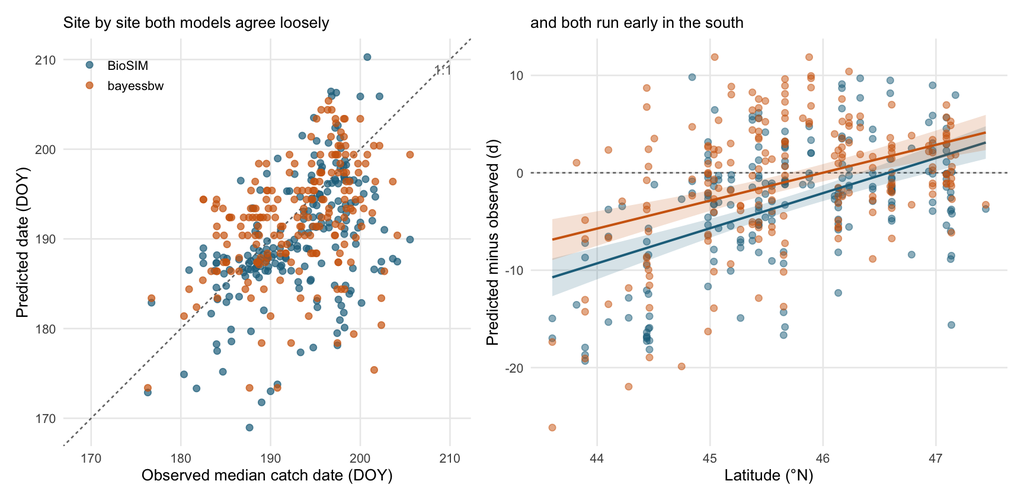

Figure 1: Two development models against the same observed catches, one point per comparable locality-year (n = 203). BioSIM is its modelled median flight date; bayessbw is its median pupation date plus the 13.4 d median pupation-to-catch interval. That shift is calibrated on these same data, so the bayessbw series sits on the 1:1 line by construction and only its scatter is informative. Left: predicted against observed median date. Right: the same offsets against latitude, with an ordinary least-squares fit per model.

Table 29: Where the agreement is, and where it is not. Correlations over the 203 comparable locality-years

| Comparison | BioSIM | bayessbw |
| --- | --- | --- |
| Predicted against observed, all locality-years | 0.49 | 0.38 |
| Year means (years with 5 or more localities) | 0.84 | 0.72 |
| Within years, across localities | 0.20 | 0.08 |
| Offset against latitude | 0.51 | 0.40 |
| Offset against log10 season total | 0.27 | 0.16 |

This is the substantive result of the comparison, and it has three parts.

Table 30: Localities with at least three comparable years and a median offset beyond a week in either model

| Location | years | latitude | median catch | BioSIM, d | bayessbw, d |
| --- | --- | --- | --- | --- | --- |
| Brunswick Township, Maine | 5 | 43.89 | 320.0 | -17.9 | -13.0 |
| Blue Hill Township, Maine | 8 | 44.44 | 377.5 | -16.6 | -3.6 |
| Mount Vernon Township, Maine | 4 | 44.46 | 180.5 | -16.6 | -12.7 |
| Millinocket, Maine | 4 | 45.65 | 615.0 | -11.8 | -9.3 |
| Milton Township, Maine | 4 | 44.45 | 293.5 | -10.4 | -2.7 |
| St. Francis Township, Maine | 3 | 47.14 | 375.0 | -8.5 | -1.4 |
| Enfield Township, Maine | 4 | 45.27 | 401.5 | -7.4 | -3.6 |
| Pittston Farm, T2 R4, Maine | 4 | 45.89 | 457.5 | 2.0 | 9.2 |
| St. Cyprien, T8 R19 (Somerset Co.), Maine | 3 | 46.33 | 923.0 | 7.7 | 4.7 |
| Round Mountain, T11 R8, Maine | 3 | 46.60 | 2159.0 | 8.2 | -1.4 |

The worst-fitting sites are southern and coastal — the same localities that the weather section found to have the coolest Julys in the dataset despite their latitude. A model that is too early there is a model whose development is running too fast on those temperature series. They are also the localities that catch the fewest moths, which is a second candidate explanation and is separated from latitude below.

## 6.3 From pupation to flight

The pupal stage is missing from `bayessbw` and the trap sees only adults, so the interval between them can be measured rather than modelled.

Table 31: Days from predicted pupation to the observed median catch

| Source | Median, d | Mean, d | SD, d |
| --- | --- | --- | --- |
| bayessbw pupation | 13.4 | 14.2 | 6.6 |
| BioSIM pupation | 17.5 | 18.5 | 6.7 |

The median catch falls 13.4 days after bayessbw’s pupation date and 17.5 days after BioSIM’s, a pupal period plus a few days of adult maturation in either case. The two intervals differ by the models’ disagreement on the pupation date itself (Table 26), not by anything about the pupal stage. The standard deviation of about six days is the part worth pursuing: if it is structured by temperature rather than random, it is a pupal development function waiting to be fitted.

## 6.4 Would a degree-day pupal stage help?

Table 32: Predicting the observed median catch from the predicted pupation date

| Model | Parameters | RMSE in sample, d | RMSE leave-one-year-out, d |
| --- | --- | --- | --- |
| A fixed lag, 13.4 d | 1 | 6.66 | 6.75 |
| B degree-days, base 0.0 °C, K = 260 | 2 | 6.65 | 6.76 |

## 6.5 Why no development function would help

A development model can only use temperature, so two numbers bound what it could ever achieve.

Table 33: The observed pupation-to-catch interval: what explains it

| Quantity | Value |
| --- | --- |
| Interval, mean ± sd | 14.2 ± 6.6 d |
| Mean temperature over the 14 d after pupation | 18.4 °C (15.0–22.8) |
| Correlation of the interval with that temperature | r = -0.01 |
| Best fit to that temperature (5-df spline) | R² = 0.047, residual sd 6.46 d |
| Interval sd after a per-locality constant | 3.94 d |
| Interval sd after locality and year | 3.24 d |
| Correlation of the interval with latitude | r = -0.40 |
| Correlation of the interval with July temperature | r = +0.48 |

## 6.6 What the long intervals look like

Table 34: Catch falling after the modelled flight window

| Quantity | Value |
| --- | --- |
| Share of the season’s catch after BioSIM’s flight p95, mean | 27% |
| Correlation of that share with the interval | r = +0.68 |
| Correlation of that share with latitude | r = -0.48 |

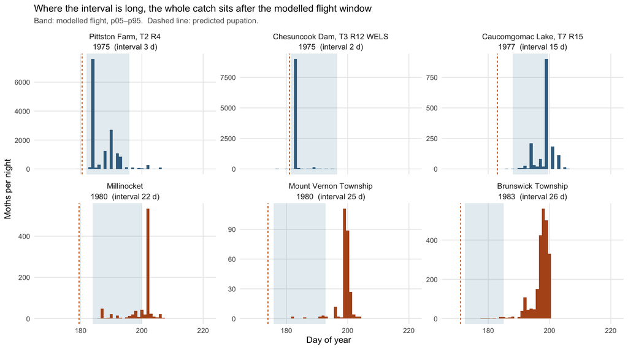

Table 35: Shape of the observed catch curve, by the length of the interval

| group | locality-years | catch before the window | inside it | after it | observed p05–p95, d |
| --- | --- | --- | --- | --- | --- |
| The other three quarters | 152 | 6% | 80% | 14% | 11.5 |
| Longest quarter of intervals | 51 | 0% | 34% | 66% | 11.9 |

## 6.7 Latitude, or how many moths were caught?

The offset’s spatial structure could be something simpler than geography: a percentile estimated from a few hundred moths is a poorer statistic than one estimated from twenty thousand, and the sites that fit worst are also sites that catch little. Latitude and catch size turn out to be nearly independent here (r = 0.22 across locality-years), so the two can be separated.

Table 36: The BioSIM offset against latitude and catch size

| Term | Value |
| --- | --- |
| Latitude, d per degree north | +3.35 (p = 0.000) |
| Catch size, d per tenfold increase | +1.43 (p = 0.008) |
| R², latitude alone | 0.259 |
| R², catch alone | 0.072 |
| R², both | 0.285 |
| Variance unique to latitude | 0.212 |
| Variance unique to catch | 0.026 |
| Variance shared | 0.047 |

Table 37: Between localities and within them

| Comparison | r |
| --- | --- |
| Between localities (n = 48): mean offset vs latitude | 0.57 |
| Between localities: mean offset vs mean catch | 0.38 |
| Within localities (179 rows, 32 sites): offset vs catch | 0.06 |
| Within localities, year means also removed | -0.15 |

A locality’s poor years are not its low-catch years: within a site the offset does not follow the size of the catch. The effect is between localities — a property of *which sites*, not of how many moths a given season produced.

Table 38: Mean BioSIM offset by region and catch size

| region | band | locality-years | mean offset, d | sd, d |
| --- | --- | --- | --- | --- |
| South (below 45.5 °N) | 1,000 or more | 46 | -3.2 | 5.5 |
| South (below 45.5 °N) | under 1,000 moths | 45 | -8.6 | 7.2 |
| North | 1,000 or more | 64 | -0.2 | 4.6 |
| North | under 1,000 moths | 48 | -2.1 | 5.8 |

The worst-fitting sites are both southern and habitually small-catch, so their offsets cannot be assigned to either cause alone. Southern localities that caught in the thousands sit far closer to the model.

| Group | Location | years | lat | median catch | median offset, d |
| --- | --- | --- | --- | --- | --- |
| Southern, large catch | Passadumkeag Township, Maine | 3 | 45.18 | 8688.0 | -5.5 |
| Southern, large catch | Meddybemps Township, Maine | 6 | 45.03 | 11854.5 | -3.7 |
| Southern, large catch | Greenbush Township, Maine | 1 | 45.07 | 10284.0 | -0.7 |
| Southern, large catch | Kingfield Township, Maine | 3 | 44.98 | 32153.0 | -0.2 |
| Worst fitting | Brunswick Township, Maine | 5 | 43.89 | 320.0 | -17.9 |
| Worst fitting | Blue Hill Township, Maine | 8 | 44.44 | 377.5 | -16.6 |
| Worst fitting | Mount Vernon Township, Maine | 4 | 44.46 | 180.5 | -16.6 |
| Worst fitting | Millinocket, Maine | 4 | 45.65 | 615.0 | -11.8 |
| Worst fitting | Milton Township, Maine | 4 | 44.45 | 293.5 | -10.4 |

## 6.8 Is the catch-size effect precision, or biology?

Part of it is precision. The spread of the offset is about twice as wide at small catches as at large ones — sd 7.3 d below a thousand moths against 4.5 d above five thousand — which is what estimating a percentile from few moths does.

Precision alone, though, produces scatter, not a shift, and a detection threshold — the mechanism that would produce one — makes a specific prediction: it should clip the sparse early nights, delaying the observed start and *narrowing* the observed curve. The data go the other way.

Table 40: Shape of the observed catch curve against catch size

| Quantity | r with log10 catch |
| --- | --- |
| Share of catch after the modelled flight window | -0.30 |
| Share of catch before it | 0.06 |
| Observed p05–p95 width | -0.23 |

It also sharpens the immigration hypothesis into something testable. If the late weight came from moths arriving rather than from the local cohort, it should matter most where the local population is small — which is what the negative correlation with catch size says — and those late nights should coincide with conditions that carry moths, which the extracted wind fields can be asked directly. The alternative reading is that a small catch reflects a site marginal for the insect, where the local cohort is both sparse and genuinely late; distinguishing the two needs the nightly weather, not more summary statistics.

# 7 Is flight synchronous across Maine?

Section 6 leaves both models early in the south, and Section 6.4 rules out a missing pupal stage as the cause. That leaves a site-level effect neither model contains, and immigration — a locality’s catch need not be its own cohort. `R/07_flight_synchrony.R` tests the second without using weather at all, by asking whether southern catches happen on the region’s dates or on their own. Two predictions separate the explanations: a wave of moths arriving from the north would flatten the latitudinal gradient in catch dates, and at nightly resolution it would make distant localities spike on the same calendar nights.

## 7.1 The latitudinal gradient

Table 41: Days per degree of latitude, with year fixed effects so that the interannual signal common to all localities is removed

| Series | n | d per °N | 95% CI | implied spread, d |
| --- | --- | --- | --- | --- |
| Observed median catch | 203 | +0.66 | +0.07 to +1.24 | 2.5 |
| BioSIM modelled flight | 203 | +4.17 | +3.43 to +4.90 | 16.0 |
| bayessbw pupation | 203 | +2.99 | +2.30 to +3.69 | 11.5 |
| Observed, catches of 1,000 or more | 110 | +0.61 | -0.37 to +1.58 | 2.3 |
| Observed, catches of 5,000 or more | 55 | +0.45 | -1.15 to +2.06 | 1.7 |
| BioSIM, catches of 1,000 or more | 110 | +3.26 | +2.15 to +4.36 | 12.5 |

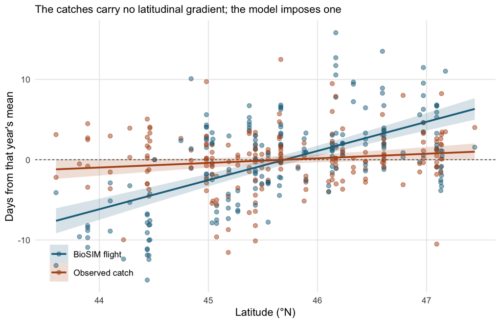

Table 42: South minus north in each year with at least two localities in both halves of the network (split at 45.5 °N)

| Year | northern localities | southern | observed gap, d | modelled gap, d |
| --- | --- | --- | --- | --- |
| 1969 | 3 | 2 | -1.0 | -11.2 |
| 1971 | 8 | 3 | -4.8 | -4.1 |
| 1972 | 7 | 2 | 2.0 | 1.0 |
| 1973 | 12 | 4 | -1.1 | -2.0 |
| 1974 | 12 | 7 | 1.0 | -10.3 |
| 1975 | 13 | 9 | -5.2 | -3.3 |
| 1976 | 8 | 5 | -6.0 | -6.2 |
| 1977 | 6 | 4 | -3.1 | -7.5 |
| 1978 | 8 | 4 | 0.7 | -2.4 |
| 1979 | 4 | 6 | 5.6 | -3.6 |
| 1980 | 5 | 10 | -2.8 | -7.2 |
| 1981 | 5 | 7 | -1.0 | -6.8 |
| 1982 | 6 | 9 | -0.2 | -5.3 |
| 1983 | 6 | 10 | -1.4 | -8.8 |
| 1984 | 2 | 3 | -5.1 | -14.8 |
| 1985 | 3 | 3 | -7.9 | -14.0 |

Averaged over those 16 years the southern localities catch their moths 1.9 days before the northern ones; the model puts them 6.7 days ahead. Seasonal timing across the network is, to within a couple of days, the same everywhere.

This reframes the residual of Section 6. What looked like a southern site effect is a **gradient-slope error**: both models spread flight across Maine about seven times more than the catches do, and the offset we were measuring is the difference between a steep modelled gradient and a flat observed one. It also explains why both models show it despite running on different weather, and why the worst sites are the extreme ones.

## 7.2 Nightly synchrony

A flat seasonal gradient is consistent with immigration, but also with a regionally synchronous emergence that the models exaggerate. The nightly curves separate the two: arriving moths should make distant localities spike together.

Table 43: Correlation of nightly catch shares between localities trapped in the same year. The null pairs the same two localities in different years, averaged over 20 draws

| Pair | pairs | median r | % above 0.5 | median distance, km | median best lag, d |
| --- | --- | --- | --- | --- | --- |
| North – north | 396 | 0.23 | 26 | 101 | 0 |
| North – south | 628 | 0.16 | 17 | 192 | 0 |
| South – south | 258 | 0.22 | 25 | 128 | 0 |

Over all 1282 pairs the median correlation is 0.20 against a shuffled-year null of -0.04, and 21% of pairs exceed 0.5 against 6% in the null. So same-night synchrony is real. It is also **local**:

Table 44: Nightly synchrony against separation

| Separation | pairs | median r | % above 0.5 |
| --- | --- | --- | --- |
| under 50 km | 56 | 0.26 | 30 |
| 50–100 | 280 | 0.25 | 28 |
| 100–200 | 609 | 0.21 | 21 |
| 200–400 | 335 | 0.14 | 13 |
| over 400 | 2 | -0.07 | 0 |

Synchrony decays with distance, and the north–south pairs are the weakest of the three types despite having the same null. The best lag is zero days for every pair type, so there is no systematic delay of the kind transport would impose.

That is the opposite of what a northward wave delivering the southern catch would produce. What the nightly data show is nearby traps sharing flight nights — local weather gating flight and trappability — and southern traps sharing few nights with northern ones.

## 7.3 What this says about immigration

The hypothesis survives at the seasonal scale and fails at the nightly one. The more parsimonious reading of both results is that real flight across Maine is nearly synchronous and that both development models exaggerate how strongly latitude and temperature spread it: the gradient is wrong, rather than the southern catch being foreign.

One caveat keeps immigration alive: arrivals need not be simultaneous across localities, because the wind fields differ from night to night, so weak north–south nightly correlation is not proof of absence.

A second candidate — that the gradient is really topography, since BioSIM was run with `elev = NaN` and the CaSR extraction carries no terrain — is tested in Section 7.4 below and ruled out.

That leads directly to a test of how much site-specific weather is buying us at all, which is Section 7.6 below: if flight is regionally synchronous, one regional weather series should predict the catches about as well as a model run at each trap’s own coordinates.

## 7.4 Is the gradient an elevation error?

Elevation is the obvious suspect for a gradient that is too steep. `R/03` leaves it unspecified, so BioSIM takes it from its own digital elevation model, and elevation is itself a latitude proxy in this network: the southern localities are coastal lowlands and the northern ones sit above 300 m (median 68 m against 303 m, r = 0.56 with latitude). `R/08_elevation_check.R` fetches an elevation for every locality from the USGS 3DEP point-query service — 7 to 573 m, median 218 — and asks BioSIM the same question twice, once with its own elevation model and once with the measured value.

Elevation does move the model. Over the plausible range of 100 to 500 m the flight date shifts by -1.9 d per 100 m at Blue Hill Township and +1.2 d per 100 m at Clayton Lake, against a run-to-run noise of about a tenth of a day. The two signs are not a typo: at the coastal locality a *higher* assumed elevation brings flight *earlier*, which cannot be a lapse rate and suggests that elevation also enters BioSIM’s choice and weighting of source weather stations — coastal stations at low elevation have cool summers. The mechanism is not established here; what matters is that the model is demonstrably sensitive.

Table 45: Modelled flight with BioSIM’s own elevation model against modelled flight with the measured elevation, over a sample of locality-years spanning the latitude range

| Quantity | Value |
| --- | --- |
| Locality-years compared | 20 |
| Mean shift when the measured elevation is supplied | -0.1 d |
| Mean shift, southern localities | +0.1 d |
| Mean shift, northern localities | -0.2 d |
| Mean absolute offset against the catches | 5.7 d → 5.9 d |
| Latitude gradient of modelled flight | +4.43 → +4.33 d per °N |
| Latitude gradient of the observed catches | -0.20 d per °N |

## 7.5 How precisely does the location have to be right?

The elevation work turned up something that does matter. A modelled date at a coastal locality is not a smooth function of where the point is: displacing the same trap eastwards in steps, with BioSIM’s own elevation model each time, moves the answer by three days inside the first kilometre and then wanders back.

Table 46: The coastal locality of the scan, displaced eastwards in steps of longitude

| displacement, km | flight p50 | shift, d |
| --- | --- | --- |
| 0.00 | 181.8 | +0.0 |
| 0.40 | 181.8 | -0.0 |
| 0.79 | 179.2 | -2.6 |
| 1.59 | 179.2 | -2.6 |
| 3.97 | 181.6 | -0.2 |
| 7.95 | 182.5 | +0.7 |

That is not a lapse rate or a distance effect; it is what a discrete set of source weather stations looks like when a point crosses from one interpolation neighbourhood into another. Two consequences. A modelled date cannot be attributed to a trap more finely than a few days at a coastal site, which matters because the recorded coordinates in this dataset carry a stated uncertainty of one to eight kilometres — though that uncertainty does not predict the size of the offset (Section 6), so this behaves as noise rather than as a bias. And a locality must always be queried at its recorded coordinates: an earlier version of this work used a coordinate rounded to two decimals from memory, landed 1.5 km away, and read that as evidence that BioSIM’s elevation model was wrong at the coast. It was not.

## 7.6 Does site-specific weather help at all?

If flight is as synchronous as Section 7 suggests, a model driven by one regional weather series — a single prediction per year, the same for every locality — should predict the catches about as well as the site-specific runs. `R/09_regional_weather_test.R` builds that comparison. The regional BioSIM run is one point at the centroid of the trap network (45.64 °N, 69.12 °W); the regional bayessbw run is the same simulation as Section 6.4 driven by the hourly temperature averaged over all localities. Each predictor is given one intercept, fitted on the other years, so a constant bias is not charged against any of them and none is scored on its own year.

| Predictor | varies by site | n | RMSE, d | MAE, d | r |
| --- | --- | --- | --- | --- | --- |
| BioSIM, site-specific | yes | 203 | 6.57 | 5.01 | 0.49 |
| BioSIM, one regional point | no | 203 | 4.38 | 3.45 | 0.65 |
| bayessbw, site-specific | yes | 203 | 6.73 | 5.13 | 0.38 |
| bayessbw, one regional run | no | 203 | 5.13 | 4.11 | 0.52 |
| Other localities that year | yes | 201 | 3.80 | 2.74 | 0.74 |

The last line of the table is the floor: the mean observed date of the *other* localities trapped in the same year, which is what a perfect regional predictor would look like. At 3.80 days it is only 0.59 days better than regional BioSIM, so the regional run already captures most of the predictable signal, and what the site-specific runs add on top of it is error.

Table 48: The regional predictions year by year, against the mean observed date. The intercepts of Table 47 are not applied here, so the columns differ by a constant

| Year | localities | observed mean | BioSIM regional | BioSIM site mean | bayessbw regional |
| --- | --- | --- | --- | --- | --- |
| 1968 | 2 | 198.5 | 198.7 | 190.3 | 182.0 |
| 1969 | 5 | 198.9 | 203.3 | 194.4 | 184.0 |
| 1970 | 3 | 192.0 | 200.5 | 193.4 | 183.0 |
| 1971 | 11 | 197.3 | 196.3 | 193.2 | 182.0 |
| 1972 | 9 | 196.6 | 197.7 | 193.2 | 184.0 |
| 1973 | 16 | 191.1 | 194.2 | 190.0 | 181.0 |
| 1974 | 19 | 197.7 | 198.6 | 196.8 | 185.0 |
| 1975 | 22 | 187.7 | 190.0 | 186.4 | 177.5 |
| 1976 | 13 | 186.3 | 190.3 | 185.2 | 174.0 |
| 1977 | 10 | 194.6 | 196.4 | 189.8 | 179.0 |
| 1978 | 12 | 188.7 | 195.1 | 187.7 | 178.0 |
| 1979 | 10 | 193.0 | 194.5 | 187.0 | 171.0 |
| 1980 | 15 | 196.6 | 203.2 | 194.2 | 181.0 |
| 1981 | 12 | 184.9 | 188.3 | 179.9 | 172.0 |
| 1982 | 15 | 198.4 | 196.9 | 190.7 | 179.0 |
| 1983 | 16 | 194.9 | 195.2 | 187.7 | 177.0 |
| 1984 | 5 | 190.1 | 197.3 | 190.5 | 182.0 |
| 1985 | 6 | 194.3 | 198.2 | 193.2 | 183.0 |
| 1986 | 1 | 194.2 | 198.5 | 190.7 | 179.0 |
| 1989 | 1 | 188.9 | 190.3 | 187.7 | 179.0 |

Two caveats on the comparison. The regional predictors cannot capture real site-to-site variation, because they are constant within a year — the result is not that no such variation exists, but that it is smaller than the error the models make when they try to represent it. And averaging temperature before running a development model is not the same as averaging the development of each site, since the rate curves are non-linear; the regional bayessbw run is a model of the average weather, not an average of the models.

Taken with Section 7 this is the practical conclusion of the comparison. For predicting when spruce budworm flies in Maine, the useful signal in these models is the year, not the site; and a phenology model applied at a single trap’s coordinates will be wrong by about six days, mostly because it imposes a latitudinal gradient the moths do not follow. Section 8 turns that finding into a predictive model and measures what it can do.

# 8 Predicting the nightly catch curve

Everything so far has compared summary dates. This section asks the predictive question directly: given a development model, how well can the **shape of a season** be predicted at a locality — the share of its catch falling on each night?

Abundance is deliberately not predicted. Nothing in this project forecasts population density, so every model below carries one free level per locality-year that absorbs the season total and leaves only timing to explain. A Poisson likelihood with such a level per group is a multinomial over that group’s nights, so the fitted values read directly as predicted shares, and a held-out locality-year needs no level of its own.

`R/10_nightly_count_model.R` fits 9 such models to 7,481 trapped nights from 203 locality-years (50% of nights caught nothing) and scores them leave-one-year-out.

Table 49: The nine specifications

| Model | What drives the shape |
| --- | --- |
| `clim` | a seasonal curve only, `ns(day of year)` fitted from the other years — the climatological baseline any predictor must beat |
| `raw` | BioSIM’s site curve used as is, no fitted parameters |
| `site` | the same curve with a free exponent |
| `site+` | plus a spline correction in days from the modelled median |
| `reg+` | the same, driven by one regional BioSIM curve per year |
| `reg+lat` | plus a latitude interaction |
| `pup+` | the same calibration applied to bayessbw’s predicted pupation distribution instead of BioSIM’s flight curve, locality by locality |
| `pupreg+` | and to one regional bayessbw run per year |
| `reg-med` | the regional curve stripped out entirely, leaving only the spline in days from its median: the development model contributes a date and nothing else |

The two bayessbw rows need no lag constant. The correction is a spline in days from the driving curve’s own median, so the interval between pupation and the catch is fitted rather than assumed — which is what made the shifted series on Figure 1 uninformative about level and is repaired here.

Table 50: Leave-one-year-out skill. Log-likelihood is the multinomial log-likelihood of the observed counts given the predicted shares, reported per moth so that it reads as a mean log predicted share

| model | log-lik per moth | mean \|p50 error\|, d | RMSE p50, d | bias, d | within 5 d |
| --- | --- | --- | --- | --- | --- |
| clim | -3.35 | 5.09 | 5.94 | 0.06 | 53% |
| raw | -3.43 | 5.04 | 6.76 | -3.00 | 62% |
| site | -3.11 | 4.54 | 6.09 | -2.08 | 64% |
| site+ | -3.07 | 4.58 | 6.24 | -1.55 | 65% |
| reg+ | -2.99 | 3.21 | 4.28 | -0.24 | 80% |
| reg+lat | -3.01 | 3.31 | 4.41 | -0.33 | 79% |
| pup+ | -3.27 | 4.85 | 6.32 | -0.84 | 61% |
| pupreg+ | -3.34 | 4.25 | 5.34 | -0.39 | 63% |
| reg-med | -3.05 | 3.21 | 4.25 | -0.04 | 80% |

Four things come out of that table.

**A calibrated regional curve is the best predictor**, and it is a usable one: 3.2 days of mean absolute error on the median catch date, a bias of -0.2 days, and 80% of locality-years inside five days — all out of sample, and with no information from the year being predicted.

**Almost all of the shape is empirical.** The fitted exponent on the regional curve is 0.24, so the modelled curve enters the prediction heavily damped. `reg-med` settles how much it is worth by removing it altogether and keeping only the spline in days from its median: that costs nothing on timing (3.21 days of mean absolute error against 3.21, the same 80% inside five days) and a little on the nightly likelihood (-3.05 against -2.99 per moth). So what the development model contributes is *when* the season is centred — which year runs early, which runs late — and the curve’s own form adds only a marginal sharpening of the nightly fit.

Measured on the trapped nights, where the fit is supported, the correction moves the predicted median +2.8 days relative to BioSIM’s curve as delivered, with a spread of 5.7 days across locality-years, and it widens the predicted central 90% from 13.9 to 15.8 days. The observed central 90% is 11.2 days, so the calibrated prediction is well centred and too broad. Part of that gap is not model error: the observed width is one realisation of a very overdispersed count and a spiky realisation is narrower than the mean curve behind it. Section 10 measures it properly by simulating realisations, and the over-width survives at about two and a half days rather than the five this comparison suggests.

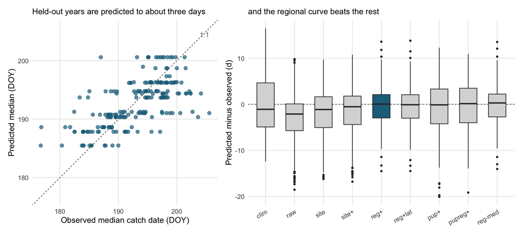

Figure 4: Out-of-sample prediction of the median catch date. Left: the calibrated regional model against the observed median, one point per locality-year, with the 1:1 line. Right: the distribution of signed errors for each specification; the box spans the quartiles, the line is the median, whiskers reach 1.5 times the interquartile range.

Table 51: Where the calibrated regional model still misses

| Quantity | Value |
| --- | --- |
| Mean \|error\|, southern localities (below 45.5 °N) | 3.71 d |
| Mean \|error\|, northern localities | 2.80 d |
| Error against latitude | r = -0.15 |
| Error against log10 season total | r = +0.12 |
| Worst locality-year | St. Francis Township 1971, -14.5 d |

Calibration removes most of the spatial structure: the residual’s correlation with latitude falls to -0.15 from the +0.49 of Section 6. A southern excess survives — mean absolute error 3.7 days against 2.8 in the north — so the gradient is corrected on average rather than explained.

## 8.1 What this model is and is not good for

It predicts **timing**, out of sample, to about three days on the median and within five days four times out of five. That is enough to say when a flight season will be centred at a Maine locality given the year’s weather, which is the operational question. Its predicted **spread** is too wide by about half again, so a prediction interval taken straight from the fitted curve will be conservative.

It does not predict **how many** moths will be caught: the season total is an input, not an output. It also does not separate flight from trappability. Nightly weather is absent by design, and the model’s own diagnostics show where that would pay: 50% of nights caught nothing, and the count variance is several thousand times the mean, so the nightly residual is dominated by night-to-night variation that a development model cannot address. Temperature, wind and precipitation at each locality-night are already extracted and would enter this model as covariates without changing anything else about it.

# 9 What distribution describes a night’s catch?

The marginal distribution of nightly counts is not a useful target: these nights differ enormously in what they should hold, from a locality-year totalling a hundred moths to one totalling seventy thousand, and within a season from the first night of flight to the peak. The question worth asking is conditional — **given what a night is expected to hold, how is the count scattered around it?**

`R/11_count_distribution.R` gives every candidate the same mean structure, the `reg+` predictor of Section 8 with a locality-year level, and varies only the distribution of the count around that mean.

Table 52: Conditional distributions for a night’s catch, same mean structure throughout. Zero-catch nights and the largest count are posterior predictive checks: the median over 100 simulations from each fitted model

| Family | par | AIC | ΔAIC | zero nights | largest count |
| --- | --- | --- | --- | --- | --- |
| poisson-ln | 8 | 46220 | 0 | 3543 | 801,923 |
| nbinom2 | 8 | 46379 | 159 | 3685 | 100,658 |
| zinb | 9 | 46381 | 161 | 3687 | 89,439 |
| nbinom1 | 8 | 47528 | 1308 | 3965 | 6,673 |
| poisson | 7 | 2553113 | 2506893 | 1099 | 17,000 |

Observed: **3,715 zero-catch nights** of 7,481, and a largest count of 27,500 moths.

**The Poisson is hopeless**, by 2,506,893 AIC. It expects 1099 empty nights where 3,715 occurred. The raw variance-to-mean ratio of the catches is 6,697.

**The variance is quadratic in the mean, and the negative binomial has it right.** Binning nights by their expected catch gives an empirical variance-mean slope of 1.83 on the log scale, where 1 is the Poisson and `nbinom1` and 2 is the negative binomial (NB2). `nbinom1`, which forces slope 1, is beaten by 1,308 AIC, and NB2’s fitted variance function tracks the binned data across three orders of magnitude (Figure 5).

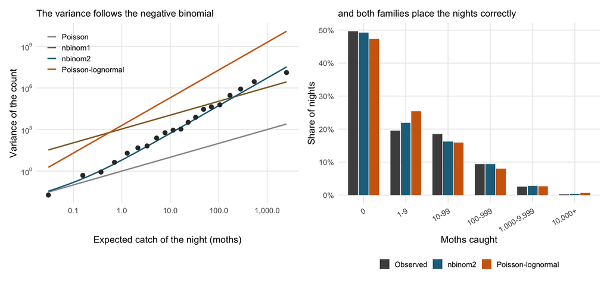

Figure 5: Left: variance against expected catch for nights binned into twenty groups, with the variance function each family assumes. Points are binned on the negative binomial’s fitted mean, which conditions on the locality-year level only; binning on the Poisson-lognormal’s fitted values would condition on its nightly random effect and collapse the points onto the Poisson line. Right: the share of nights in each count band, observed and simulated from each fitted model.

Both statements can hold at once because a lognormal mixture this wide is extremely right-skewed: most nights sit near its median, which is what the likelihood rewards, while its mean and variance are carried by rare enormous nights that the data do not contain.

## 9.1 The answer, and what it is for

- For **describing or predicting nightly catches** — regression, prediction intervals, simulation — the **negative binomial (NB2)** is the distribution best adapted to these data: variance 5.3 times the squared mean on top of the Poisson term, matching the empirical variance-mean relation across three orders of magnitude, with the better-behaved upper tail.
- The **Poisson-lognormal** is the better *description of the bulk* and the more interpretable mechanism — nightly catchability as a multiplicative random factor — but its second moment and tail are wrong, so it should not be used to simulate extremes.
- **Do not zero-inflate.** The empty nights need no separate mechanism.
- Neither family should be trusted for extreme quantiles: both overstate the largest catches.

Whichever is used, the size of the nightly term is the finding worth carrying forward. A standard deviation of the nightly multiplier of 2.3 times the mean under NB2 — an order of magnitude in each direction under the lognormal — dwarfs everything the development models disagree about: a ten-day error in the modelled median changes a given night’s expected catch by less than the night-to-night noise. It also explains the shape of these curves directly. A third of a season’s catch arriving on its single best night (Section 6.4) is not a curious feature of spruce budworm flight; it is what a nightly multiplier of this size produces on a seasonal curve of ordinary width.

One caveat on the fitting. `glmmTMB` warns that it was built against a different version of `TMB` than the one installed here. The two leading fits were therefore repeated with `lme4` — the Poisson-lognormal as an observation-level random effect, the negative binomial through `glmer.nb` — which reproduced the log-likelihoods to within 3 AIC and the nightly standard deviation to three decimals, so the ranking does not rest on that warning.

# 10 Forecasting from what a forecast has

The sections above ask what the models get right. This one fixes the inputs a forecast would actually have for a locality-year and asks how well the flight season can be predicted from them:

1. a distribution of developmental dates — **pupation** from bayessbw, or **adult emergence** from BioSIM;
2. **hourly temperature** at the locality;
3. the season’s **total catch**.

No trap data from the year being predicted. The season total being an input is what makes this tractable: abundance is not modelled, only the share of that total falling on each night.

## 10.1 The distribution of adult dates

BioSIM’s `Adults` column, kept in Section 4, is a stock — it re-counts the same individuals every day and sums to about 1,500% of the cohort, so it is not a distribution. The series that is one is **`MaleEmergence + FemaleEmergence`**, which sums to exactly 100%. At the regional point in 1978 it is centred on day 190.4 with a central 90% of 13.2 days, against 194.7 and 14.4 days for the flight curve: emergence is four days earlier and slightly narrower, as it should be. This section is the first use of it.

## 10.2 Nightly temperature

Flight is crepuscular, so temperature is averaged over the hours 20:00 to 02:00 of each trap-night, with the hours after midnight assigned to the night that began the previous evening. Every one of the 7,481 trapped nights has a complete window.

## 10.3 Timing and nightly skill

Table 53: Leave-one-year-out skill from forecast inputs only. `+ temp` adds the nightly flight-hour temperature as a quadratic. All specifications are negative binomial with a locality-year level, so the season total is conditioned on rather than predicted

| Specification | median error, d | RMSE, d | log score per moth | 90% coverage |
| --- | --- | --- | --- | --- |
| flight (R/10 best) | 3.23 | 4.30 | -2.962 | 93% |
| flight + temp | 3.25 | 4.36 | -2.901 | 93% |
| emergence + temp | 3.33 | 4.36 | -2.945 | 94% |
| emergence | 3.44 | 4.38 | -3.061 | 94% |
| pupation + temp | 4.68 | 6.39 | -3.075 | 93% |
| temperature only | 4.82 | 6.03 | -3.248 | 93% |
| pupation | 4.93 | 6.50 | -3.239 | 93% |

## 10.4 The predicted season is genuinely too wide

Earlier sections compared the predicted mean curve’s central 90% with the observed one and called the prediction over-dispersed. That comparison is not quite fair: the observed width is measured on a single realisation of a very overdispersed count, and a spiky realisation is narrower than the smooth mean curve behind it. The check below simulates realisations from each fitted predictive distribution and measures their widths exactly as the observed width is measured.

Table 54: Central 90% of the flight season: the smooth mean curve, a simulated realisation of it (100 draws per locality-year), and the observed value. The last column is the share of locality-years whose observed width falls inside the simulated 90% band

| Specification | mean curve, d | realisation, d | observed, d | inside the band |
| --- | --- | --- | --- | --- |
| flight + temp | 13.6 | 13.2 | 11.6 | 76% |
| pupation + temp | 15.7 | 14.8 | 11.6 | 73% |
| flight (R/10 best) | 14.0 | 13.3 | 11.6 | 71% |
| emergence | 14.8 | 14.0 | 11.6 | 70% |
| emergence + temp | 14.5 | 13.9 | 11.6 | 70% |
| pupation | 16.0 | 14.8 | 11.6 | 68% |
| temperature only | 16.6 | 15.7 | 11.6 | 66% |

The nightly predictive intervals are correspondingly conservative: the 90% negative binomial interval, with the season total supplied, contains the observed count on 93% of nights.

## 10.5 Where this leaves the forecast

Table 55: The forecast as it stands

| Component | Best available | Skill |
| --- | --- | --- |
| Median flight date | BioSIM flight or emergence curve, calibrated | 3.2 d mean absolute error, out of sample |
| Which nights within the season | the same, plus nightly flight-hour temperature | log score per moth -2.901 against -2.962 without it |
| Count on a given night | negative binomial, θ from Section 9, mean = share × season total | 90% interval covers 93% of nights |
| Season width | all specifications too broad by about 2.5 d | 76% of observed widths inside the simulated band |

# 11 A callable predictor

`R/13_fit_flight_predictor.R` fits the model on every year and stores what is needed to predict a locality-year that was never trapped; `R/functions/predict_flight.R` consumes it. The call takes the three forecast inputs and nothing else:

```r
source("daily_dynamics/R/functions/predict_flight.R")

out <- predict_flight(
  dev_curve    = emergence_1978,   # data frame: doy, pct
  hourly_temp  = weather_1978,     # data frame: datetime, Temp
  season_total = 12000,            # moths caught that season
  driver       = "emergence"       # or "flight", or "pupation"
)
```

It returns one row per night: the share of the season expected that night, the expected count, and a negative binomial predictive interval. Three driver variants are stored, so whichever developmental distribution is to hand can be used — BioSIM’s flight or emergence curve, or bayessbw’s pupation distribution.

The shares are normalised over the nights supplied, so the answer is always *of this season’s catch, how much falls on each of these nights*. A window shorter than the flight season inflates every share, exactly as a trap that operates for part of the season does.

## 11.1 Sharpening, and the trade-off it forces

Section 10 leaves the predicted season two to five days too broad. The fitted shape is a log-share curve, so raising it to a power κ > 1 sharpens it around its own peak without moving the peak. κ is chosen out of sample by stacking: for each year it is the value that scores best on the *other* years’ held-out predictions.

Table 56: Held-out skill with and without sharpening. `logscore` chooses the sharpening that maximises the nightly log score; `width` chooses the one that makes the predicted season the right length

| Driver | κ chosen | κ | median error, d | width error, d | log score per moth |
| --- | --- | --- | --- | --- | --- |
| flight | none | 1.00 | 3.25 | +2.33 | -2.901 |
| flight | by log score | 1.00 | 3.25 | +2.33 | -2.901 |
| flight | by width | 1.25 | 3.26 | +0.42 | -2.953 |
| emergence | none | 1.00 | 3.33 | +3.23 | -2.945 |
| emergence | by log score | 1.00 | 3.33 | +3.23 | -2.945 |
| emergence | by width | 1.38 | 3.30 | +0.54 | -3.029 |
| pupation | none | 1.00 | 4.68 | +4.48 | -3.075 |
| pupation | by log score | 1.00 | 4.68 | +4.48 | -3.075 |
| pupation | by width | 1.51 | 4.73 | +0.78 | -3.284 |

The two criteria disagree, and the disagreement is the useful part.

**By the log score, no sharpening at all.** κ = 1 for every driver: the proper scoring rule for nightly counts prefers the broad curve, because sharpening moves mass away from the shoulders where a handful of moths still arrive, and the log score punishes that heavily.

So the choice depends on the use. For **when to expect flight and over what window** — the operational question — sharpen: the season comes out the right length at a negligible cost in the median. For **probabilistic statements about a particular night’s count**, leave κ = 1. `predict_flight()` defaults to the sharpened setting and takes `kappa = "logscore"` or a number to override.

## 11.2 A worked example

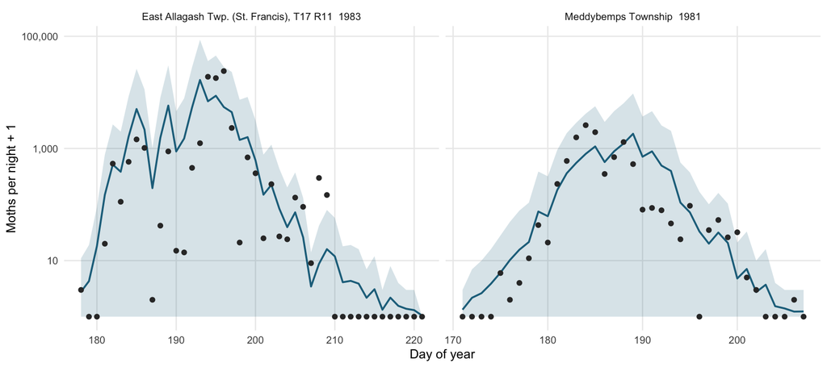

Figure 6: Two locality-years predicted from their emergence curve, hourly temperature and season total, with the sharpened shape. Line: expected catch. Band: 90% negative binomial interval. Points: the observed catches, which the model never saw for these years. Counts are plotted plus one on a log scale.

The left panel is the largest catch in the dataset, 71,730 moths over 44 nights; its median is predicted -1.9 days out, and the right panel’s +3.4 days. The temperature term is visible in both: the sharp dips are cold nights, and the observed catches dip with them — day 187 at East Allagash averaged 6.9 °C through the flight hours and caught one moth, where the neighbouring warm nights caught hundreds.

## 11.3 What it does not do

- It does not predict **abundance**: the season total is an input. Predicting that needs a population model, which nothing in this project provides.
- It has no **site term**, by design — Section 7.6 showed site-specific weather makes the timing worse, and every latitude term tried has hurt.
- It inherits the **southern excess** of Section 8: localities below 45.5 °N are fitted about a day worse than northern ones.
- Its inputs must be **regional**: the fitted variants use BioSIM run once at the network centroid. Feeding it a curve from a site-specific run is a different input from the one it was calibrated on.

# 12 The missing nights are censoring

An `m` night is not a night whose catch is unknown in the way a lottery number is unknown. It is a night inside a running trapping period whose catch was not recorded, and because flight is a seasonal curve, where the night falls decides which part of that curve is unidentified. `R/01_read_trap_data.R` therefore reads them as **censoring**: a missing night before 15 July bounds the rise of the season (left-censored), a missing night after it bounds the decline (right-censored). The side is carried on every night in `trap_daily$censoring` and counted per record in `n_cens_left` / `n_cens_right`.

Of the 30 missing nights in the working dataset, 0 are left-censored and 30 right-censored, spread over 4 records. A further 1 record was removed from the dataset because of where its censored nights fell (below).

Left-censoring has disappeared from the dataset, and not by accident: the large June blocks of `m` codes fall before the first capture of their year, so the season window of Section 2 excludes them along with the rest of the out-of-season range. Every censored night that survives is in the declining tail.

## 12.1 The side is not the magnitude

Table 57: The records where censoring is material: more than 1% of the season expected on nights with no count. `shift` is how far the percentile moves when the censored nights are completed at their expected level

[output not shown]

One record was removed from the dataset rather than flagged. Elliotsville Township in 1978 has only two censored nights — 8 and 9 July — but they sit at the peak, and the predictor expects 26% of the whole season on them: 3,205 moths against the 9,060 recorded. Completing them moves its median catch date +1.2 days and p95 -0.9 days. That is not a flight curve with a gap in it but one missing its peak, so no percentile taken from it is identifiable, and `exclude_records` in `R/01_read_trap_data.R` drops it. Its nights are kept in `data/processed/trap_excluded.rds` so this diagnostic — the one that justified the decision — still reports it.

The record passed `usable_phenology` and `flight_complete` throughout, because neither flag looks at *where* a gap falls relative to the catch. That is a limitation of those flags: a censored peak is invisible to them.

## 12.2 The published aggregates do not move

Table 58: The two headline spatial numbers, recomputed with every affected record’s percentiles completed

| Quantity | As published | Censoring completed |
| --- | --- | --- |
| median offset, d | -2.12 | -2.12 |
| observed gradient, d per degree N | +0.66 | +0.66 |

So the censoring rule changes no result reported here. What it changes is what may be done next: a record whose peak is censored should not contribute to a width or late-tail analysis at face value, and `censoring` now makes those records findable instead of leaving them indistinguishable from complete ones. The diagnostic is deliberately not a correction — nothing downstream reads the completed percentiles.

# 13 Findings so far

## 13.1 The data

226 Maine light-trap records from the Rhainds compilation cover 49 localities and 22 years (1968–1989), with 8,286 counted trap-nights, every record above 99 moths for the season. The minimum-effort rule of Section 2 marks 223 records as usable for percentile phenology; intersected with the modelled cohorts that finish flight, **203 locality-years** carry a meaningful model-versus-observed comparison. Hourly CaSR weather was extracted for all 226 locality-years (1.99 million hours).

## 13.2 Two development models that agree on the pattern, not the date

BioSIM’s `Spruce_Budworm_Biology` and the Bayesian model of bayessbw were fitted to different data, by different methods, and were driven by different weather — BioSIM’s own station network against the CaSR grid. They rank locality-years alike (r = 0.78), but BioSIM pupates a median 4.0 days earlier (Table 26), so the observed median catch follows predicted pupation by 13.4 d for bayessbw and 17.5 d for BioSIM. In the pupation model, individual variation exceeds parameter uncertainty about fourfold: a population takes 9.3 days to pupate from p05 to p95, while the posterior places its median to within 2.2 days.

## 13.3 The central finding

Against the catches, modelled flight is early by a median 2.1 days at p50 (3.7 d at p05, 1.0 d at p95). That average hides a split: year means correlate at 0.84, but within a year across localities the correlation is 0.20.

## 13.4 Five explanations tested and set aside

Table 59: What the residual is not

| Candidate | Evidence against it | Where |
| --- | --- | --- |
| The weather source | both models make the same spatial error on different weather (offsets correlate 0.71) | Section 6 |
| A temperature-driven pupal stage | degree-days beat a constant lag by -0.01 d out of sample; the interval’s correlation with post-pupation temperature is -0.01 and a spline on it reaches R² 0.047; 64% of its variance is between localit… | Section 6.4 |
| Elevation and topography | all 49 elevations measured (7–573 m); supplying them shifts flight -0.1 d and leaves the gradient at +4.3 d per degree | Section 7.4 |
| A detection threshold at low catch | small catches carry *more* of their catch after the modelled window and have slightly wider curves — the opposite of clipping | Section 6 |
| Nightly-scale immigration | 1282 within-year locality pairs give a median nightly correlation of 0.20 against a shuffled-year null of -0.04, decaying with distance, weakest north–south, at zero lag | Section 7 |

Catch size survives as a second, weaker and near-independent site covariate: +1.43 days per tenfold catch against +3.35 days per degree of latitude, and with no effect within a locality.

## 13.5 What predicts the flight season

Site-specific weather makes both models worse than a single regional series (Table 47). Built into the nightly count model of Section 8, the calibrated regional curve predicts a held-out year’s median catch date to 3.21 days of mean absolute error, bias -0.24 d, with 80% of locality-years inside five days — against 5.09 days for a seasonal climatology.

Two qualifications matter for using it. First, the development model contributes **the date, not the shape**: with an exponent of 0.24 on the modelled curve, deleting the curve entirely and keeping only its median plus the empirical correction costs nothing on timing (3.21 days). BioSIM’s uncorrected site curve, meanwhile, buys nothing over climatology — it ties on mean absolute error and is worse on RMSE, on the nightly likelihood and on bias. Second, the calibrated prediction is **over-dispersed**: it widens the predicted central 90% to 15.8 days against 11.2 observed, so an interval read straight off the fitted curve is conservative.

The distribution around that prediction is also settled (Section 9): a night’s catch is **negative binomial** with a variance about 5.3 times the squared mean, it needs no zero inflation, and the implied night-to-night multiplier varies by an order of magnitude in each direction — more than anything the development models disagree about.

bayessbw’s pupation distribution does not improve on this (4.85 d site-specific, 4.25 d regional). Its value in this project is as the independent check on pupation timing, not as the driver of the prediction.

## 13.6 A predictor that can be called

`predict_flight()` (Section 11) packages the result into the three inputs that will be available at prediction time: a developmental distribution, hourly temperature, and the season total. On held-out years it places the median catch date within about three days and, with the sharpening parameter set by width, returns a season of the right length. It predicts shares of a given total, never the total itself.

## 13.7 What is still open

- **Wind and precipitation are still unused.** Nightly temperature is now in the model (Section 10) and it is the one covariate that improves the nightly numbers, but it does not move the median; wind and precipitation are already extracted per locality-night and would enter the same way.
- **Immigration is not excluded, only unsupported at the nightly scale.** Arrivals need not be simultaneous across localities, and no systematic search for second modes has been made across the 203 curves. Millinocket in 1980 (Figure 2) is the one panel that looks like an influx.
- **The southern excess survives calibration.** The count model’s residual correlates only -0.15 with latitude, but southern localities are still fitted about a day worse than northern ones, so the gradient is corrected on average rather than explained.
- **Abundance is not modelled at all.** Every result here is about timing; the season total is an input to the predictive model, never an output.